# APM504 - Practical 1

Levi John Wolf

## Problem 1

Write a program that will simulate the Wright-Fisher model for a diploid population segregating two alleles, A and a.

Then, run 1000 simulations starting at $p_0 = .5$ to estimate the distribution of $p_t$ at times $t = \frac{N}{2}$ and $t=N$ for $N$ ranging from $10^2$ to $10^5$. What do your results suggest about the behavior of the process when time is measured in units of $N$ generations and $N \rightarrow \infty$?

### Answer:

It appears that the process will converge to one allele being fixed when the time grows large. Specifically, it appears that convergence is probable when the number of generations is large with respect to the size of the population.

### Methods:

First, the program. I will need to import a few libraries like `NumPy` and `Pickle`. `NumPy` is just a high-speed numerical library for python, and `Pickle` allows me to store data in a fast, simple binary format to avoid memory limits while processing markov chains.

```python
import numpy as np
import pickle as pk
from collections import defaultdict
import matplotlib.pyplot as plt
from depickle import *
import os
import pandas as pd
%matplotlib inline
```

With these, first I program the simulator for the Wright-Fisher model. I used the binomial sampling technique over $2N$ individuals mentioned in the practical notes. This code does one simulation for a population size `pop`, with alleles `anames` that have initial probabilities `initprobs`, for `gens` generations. This code is the basic unit of computation, which was meted out to a pool and done in parallel.

```python
def wf(pop, anames, initprobs, gens):
    results = defaultdict(dict)
    i = 0
    results[i] = {key:val for key,val in zip(anames, initprobs)}
    p = results[i][anames[0]]

    while gens > i:
        p = np.random.binomial(2*pop, p)/ float(2*pop)
        i += 1
        results[i] = {key:val for key,val in zip(anames, [p, 1-p])}

    return results
```

But, storing $S$ copties of this simulation in memory all at once may prove to be too costly. To avoid this, I use the pickle library to save the results of each simulation to a binary file, further allowing easy simulations.

Then, we can define a function to unpack the results of the computation. As required, we can calculate the probability at the middle and end generation. In addition, I'll calculate the mean value of *each* generation.

```python
n100p50 = open('./psims/n100p50.pkl')
samples, ends, means = depickle(n100p50)
```

Plotting the values in the case where $N = 100$, we see that one allele tends to fix at zero in the end and one tends to fix at 1.

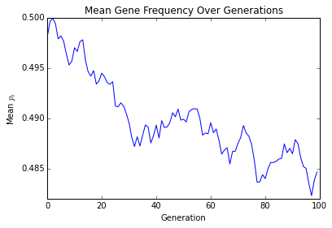

```python
plt.plot(means)
plt.title('Mean Gene Frequency Over Generations')
plt.xlabel('Generation')
plt.ylabel('Mean $p_t$')
```

The fact that there is no general convergene in the mean frequency is unsurprising. Only 150 of the simulations hit an allele frequency outside of $[.1, .99]$, with those that did end up fixing in the population occuring around generation 70.

```python
print len(ends), np.mean(ends.values())
```

```
152 72.8552631579
```

However, the distribution for the $\frac{N}{2}$ is still relatively clustered around $p_t = .5$...

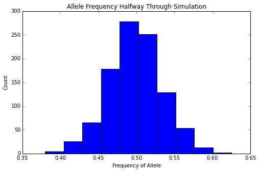

```python
a = plt.figure(figsize=(1.6*5, 5))
plt.hist([x[0] for x in samples])
plt.title('Allele Frequency Halfway Through Simulation')
plt.xlabel('Frequency of Allele')
plt.ylabel('Count')
```

and the frequency of alleles at the end of simulation looks almost uniform!

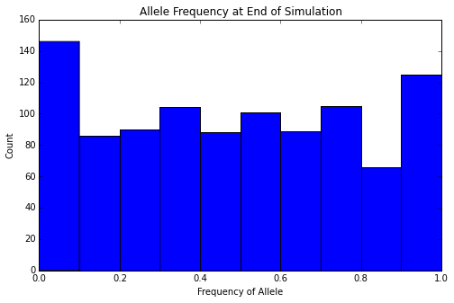

```python
b = plt.figure(figsize=(1.6*5, 5))
plt.hist([x[1] for x in samples])
plt.title('Allele Frequency at End of Simulation')
plt.xlabel('Frequency of Allele')
plt.ylabel('Count')
```

Overall, I think that exactly $N$ generations is insufficient to see these changes, for the case of $N =100$. Increasing $N$ and holding generations equal to the population size will likely also carry through these results. But, I would also expect the mean behavior of the system to converge closer to $.5$, rather than the mean behavior as shown above.

For the case where $N = 1000$, we can do the same thing:

```python
n1000p50 = open('./psims/n1000p50.pkl')
samples,ends, means = depickle(n1000p50)
```

The plot of the mean fluctuates below $.5$, but exhibits the same lack of convergence as the prior case. Notably, we still see the mean case being well above zero, as we do above. This is understandable, as minor fluctuations could push each state either upwards or downwards from an even 50-50 split of the population. This means that, on average, we should have about half as many up-fixations (allele A $\rightarrow$ 1) and down-fixations (allele A $\rightarrow$ 0), so the mean should stay relatively constant around $.5$.

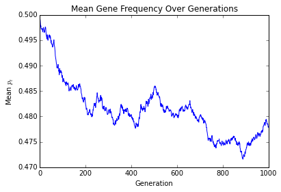

```python
plt.plot(means)
plt.title('Mean Gene Frequency Over Generations')
plt.xlabel('Generation')
plt.ylabel('Mean $p_t$')
```

Adding more generations proportional to the population did not seem to affect the probability of fixation: only 93 simulations attained an allele frequency indicating fixation, and they did so, on average, by the 750th step. This is consistent with the other cases.

```python
print len(ends), np.mean(ends.values())
```

```
93 749.301075269
```

The histograms also bear the same information as above. For the middle simulations, the values are relatively tightly clustered around the starting value. However, at the end of the simulation, the distribution is almost uniform, with slightly pronounced peaks at the corners $0$ and $1$.

[figure not shown]

```python
a = plt.figure(figsize=(1.6*5, 5))
plt.hist([x[0] for x in samples])
plt.title('Allele Frequency Halfway Through Simulation')
plt.xlabel('Frequency of Allele')
plt.ylabel('Count')
```

[figure not shown]

```python
b = plt.figure(figsize=(1.6*5, 5))
plt.hist([x[1] for x in samples])
plt.title('Allele Frequency at End of Simulation')
plt.xlabel('Frequency of Allele')
plt.ylabel('Count')
```

While this doesn't add too much new information, this is also the case for $n=10000$, $p_0= .5$. This leads further creedence to the belief that the fixation occurs at some marginally larger amount of time than exactly $N$ generations.

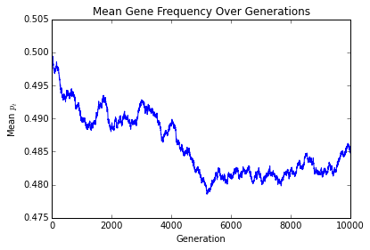

```python
n10000p50 = open('./psims/n10000p50.pkl')
samples, ends, means = depickle(n10000p50)
plt.plot(means)
plt.title('Mean Gene Frequency Over Generations')
plt.xlabel('Generation')
plt.ylabel('Mean $p_t$')
```

And again, a similar result in the fixation percentage and mean fixation time, with 177 alleles reaching fixation around generation 7000.

```python
print len(ends), np.mean(ends.values())
```

```
177 7307.24293785
```

The histograms show the same story as the other cases, with concentration around the starting frequency by the middle of the simulations and a nearly uniform, somewhat peaked distribution by the end of the simulations.

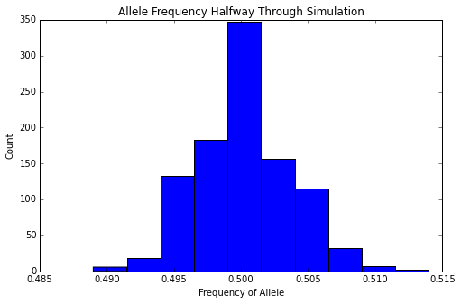

```python
a = plt.figure(figsize=(1.6*5, 5))
plt.hist([x[0] for x in samples])
plt.title('Allele Frequency Halfway Through Simulation')
plt.xlabel('Frequency of Allele')
plt.ylabel('Count')
```

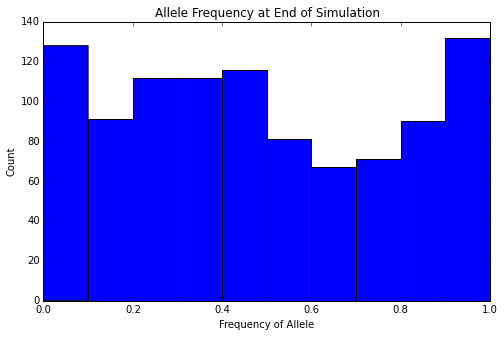

```python
b = plt.figure(figsize=(1.6*5, 5))
plt.hist([x[1] for x in samples])
plt.title('Allele Frequency at End of Simulation')
plt.xlabel('Frequency of Allele')
plt.ylabel('Count')
```

## Problem 2

Estimate the fixation probability of an allele $A$ as a function of the initial frequency by running 1000 simulations over starting frequencies $.1,.2,...,.9$. Do this for $N = 100, 1000,$ and $10000$ and compare your estimates with the theoretical result presented in class.

## Methods:

### $N=100$

```
647  Simulations Fixed in  37.6769706337 generations (avg)
```

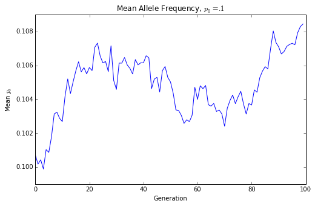

```python
meanends('./psims/n100p10.pkl', '.1')
```

```
454  Simulations Fixed in  53.359030837 generations (avg)
```

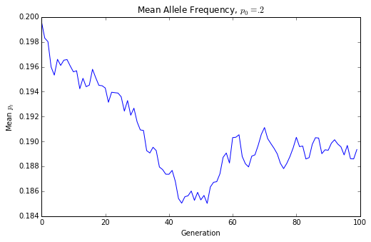

```python
meanends('./psims/n100p20.pkl', '.2')
```

```
285  Simulations Fixed in  62.0807017544 generations (avg)
```

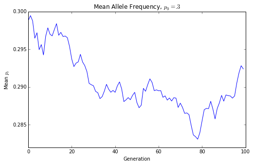

```python
meanends('./psims/n100p30.pkl', '.3')
```

```
205  Simulations Fixed in  69.9317073171 generations (avg)
```

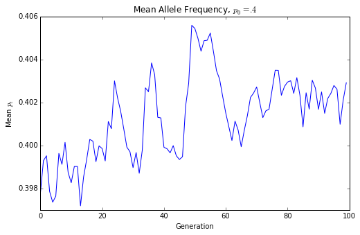

```python
meanends('./psims/n100p40.pkl', '.4')
```

```
152  Simulations Fixed in  72.8552631579 generations (avg)
```

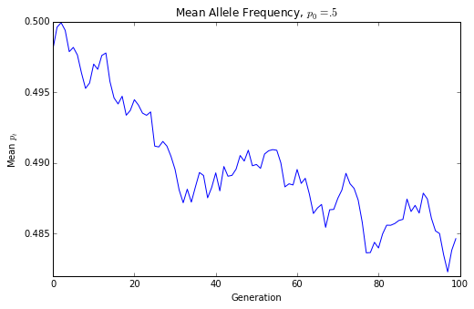

```python
meanends('./psims/n100p50.pkl', '.5')
```

```
169  Simulations Fixed in  70.6686390533 generations (avg)
```

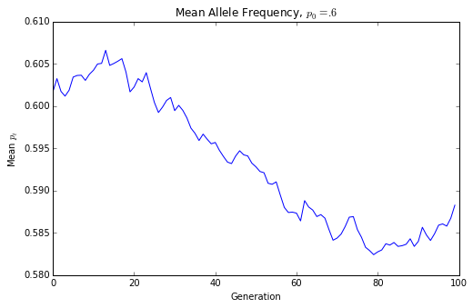

```python
meanends('./psims/n100p60.pkl', '.6')
```

```
283  Simulations Fixed in  64.0141342756 generations (avg)
```

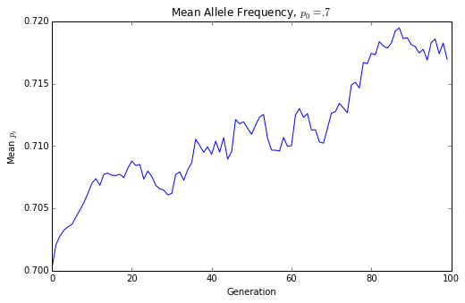

```python
meanends('./psims/n100p70.pkl', '.7')
```

```
446  Simulations Fixed in  53.2556053812 generations (avg)
```

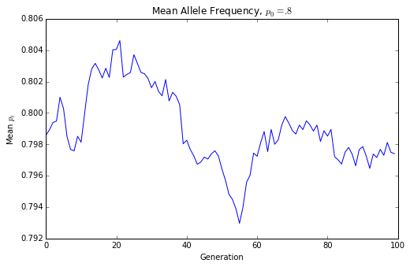

```python
meanends('./psims/n100p80.pkl', '.8')
```

```
662  Simulations Fixed in  37.3867069486 generations (avg)
```

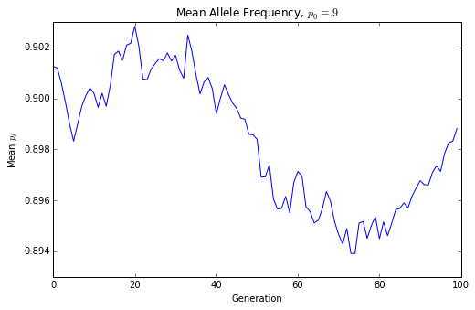

```python
meanends('./psims/n100p90.pkl', '.9')
```

### $N = 1000$

Not much information is added here. The same behavior is apparent for this set of simulations as the set when $N = 100$.

```
697  Simulations Fixed in  353.645624103 generations (avg)
```

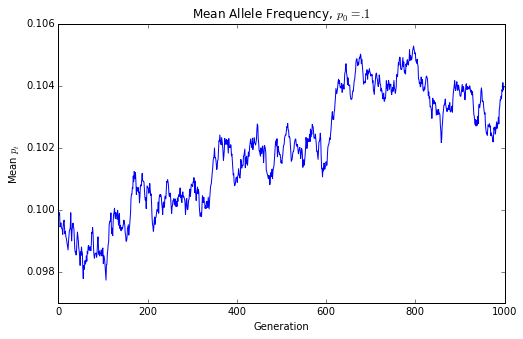

```python
meanends('./psims/n1000p10.pkl', '.1')
```

```
427  Simulations Fixed in  502.145199063 generations (avg)
```

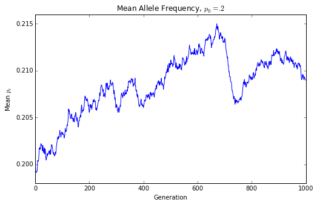

```python
meanends('./psims/n1000p20.pkl', '.2')
```

```
280  Simulations Fixed in  633.3 generations (avg)
```

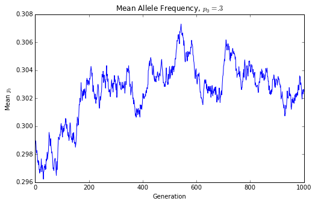

```python
meanends('./psims/n1000p30.pkl', '.3')
```

```
186  Simulations Fixed in  722.0 generations (avg)
```

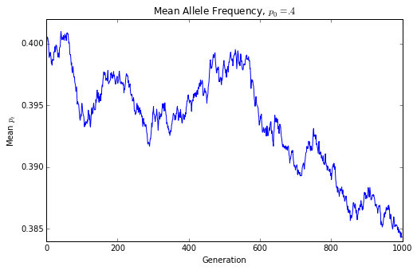

```python
meanends('./psims/n1000p40.pkl', '.4')
```

```
224  Simulations Fixed in  698.651785714 generations (avg)
```

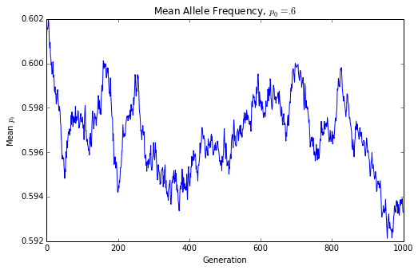

```python
meanends('./psims/n1000p60.pkl', '.6')
```

```
316  Simulations Fixed in  593.810126582 generations (avg)
```

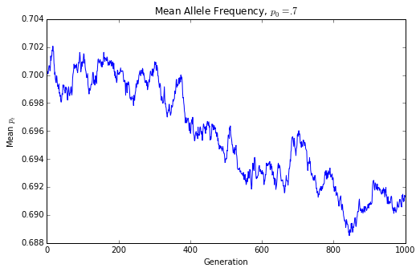

```python
meanends('./psims/n1000p70.pkl', '.7')
```

```
452  Simulations Fixed in  499.170353982 generations (avg)
```

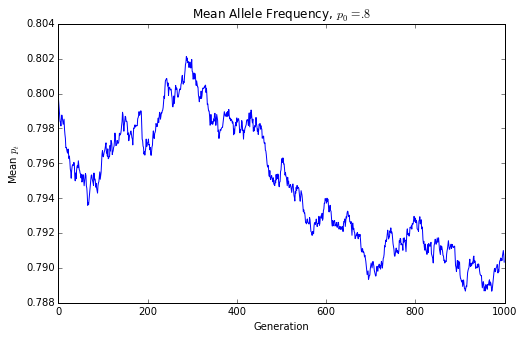

```python
meanends('./psims/n1000p80.pkl', '.8')
```

```
704  Simulations Fixed in  341.146306818 generations (avg)
```

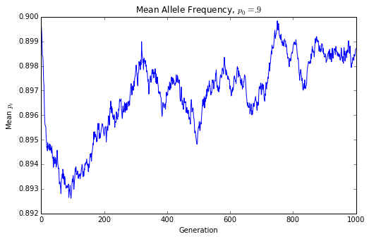

```python
meanends('./psims/n1000p90.pkl', '.9')
```

$N = 10000$

Again, almost everything that holds for the above two cases holds here.

```
688  Simulations Fixed in  3531.98255814 generations (avg)
```

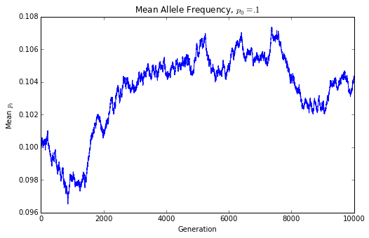

```python
meanends('./psims/n10000p10.pkl', '.1')
```

```
437  Simulations Fixed in  5228.09382151 generations (avg)
```

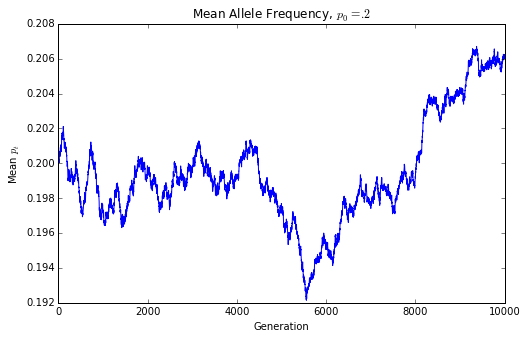

```python
meanends('./psims/n10000p20.pkl', '.2')
```

```
275  Simulations Fixed in  6148.77454545 generations (avg)
```

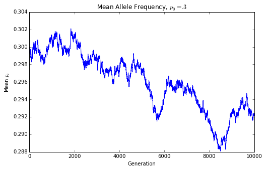

```python
meanends('./psims/n10000p30.pkl', '.3')
```

```
206  Simulations Fixed in  6736.89320388 generations (avg)
```

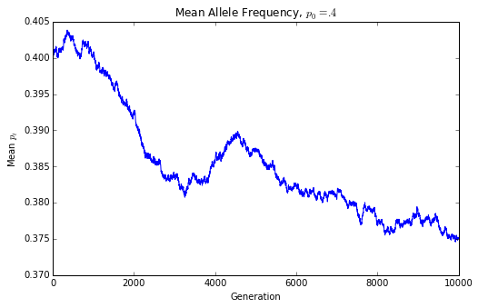

```python
meanends('./psims/n10000p40.pkl', '.4')
```

```
177  Simulations Fixed in  7307.24293785 generations (avg)
```

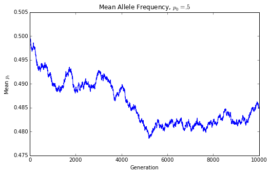

```python
meanends('./psims/n10000p50.pkl', '.5')
```

```
201  Simulations Fixed in  6849.07462687 generations (avg)
```

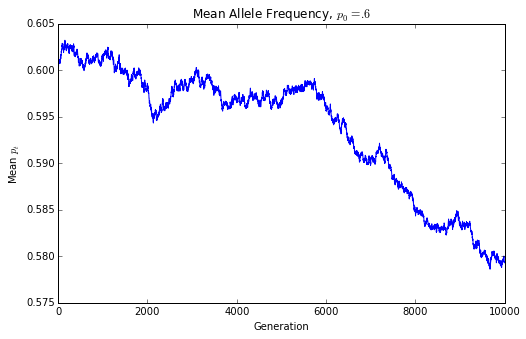

```python
meanends('./psims/n10000p60.pkl', '.6')
```

```
316  Simulations Fixed in  5920.78164557 generations (avg)
```

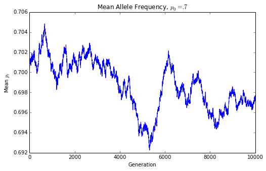

```python
meanends('./psims/n10000p70.pkl', '.7')
```

```
498  Simulations Fixed in  4858.84939759 generations (avg)
```

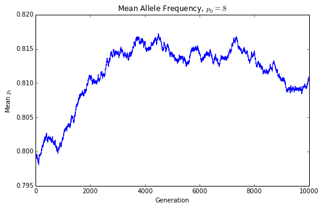

```python
meanends('./psims/n10000p80.pkl', '.8')
```

```
679  Simulations Fixed in  3392.18556701 generations (avg)
```

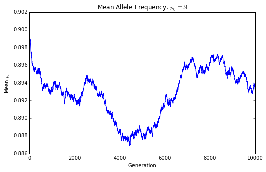

```python
meanends('./psims/n10000p90.pkl', '.9')
```